# Midterm 2 Redo

2026-03-19

## R Markdown

```r
library(tidyverse)
library(janitor)
library(naniar)
library(ggmap)
library(lubridate)
library(shiny)
```

```r
register_stadiamaps("06cd37b9-1de9-4a29-a487-f35c527a975f", write = FALSE)
```

```r
polar_bears <-
  read_csv("data/polarBear_serumUreaCreatinine_beaufortChukchi_rode.csv") %>%
  clean_names() %>%
  select(-den_method, -no_cubs, -cub_age) %>%
  filter(age_class==c("A", "S")) %>%
  mutate(sex=toupper(sex),
         age_class=toupper(age_class))
```

3. (6 points) Is sampling even for both sexes? Make a count the shows the number of males and females sampled by population and make a plot to visualize the counts.

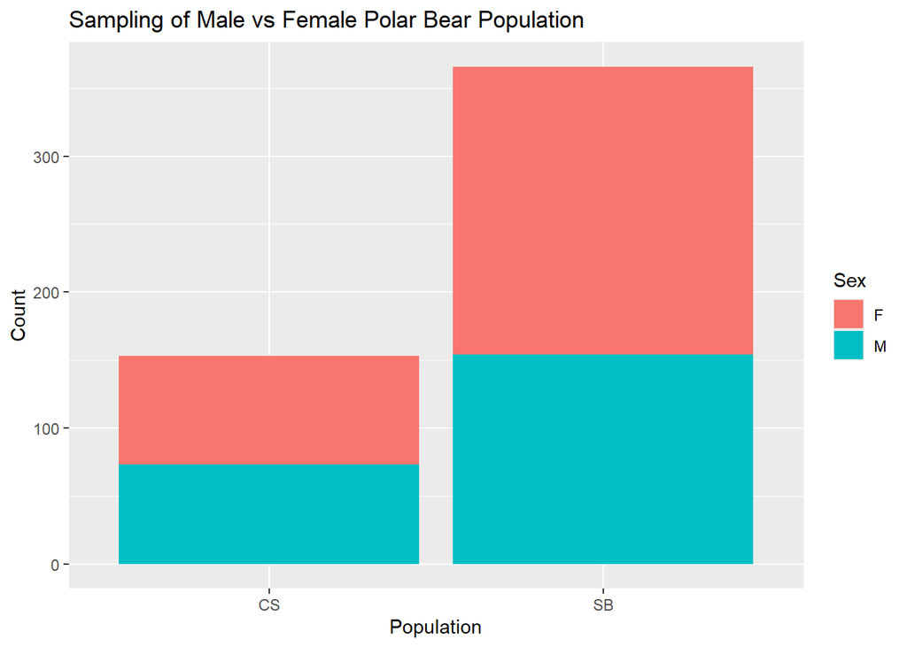

```r
polar_bears %>%
  ggplot(aes(x=popn, fill = sex))+
  geom_bar()+
  labs(title = "Sampling of Male vs Female Polar Bear Population", x="Population", y="Count", fill = "Sex")
```

No, the sampling isn’t even, there are more female bears sampled in the data.

4. (6 points) How many bears were sampled in each year for both populations? Make a line plot(s) to visualize sampling by year for both populations. (hint: you will need to pull apart the date to get the year in its own column)

```r
polar_bears_year <- polar_bears %>%
  separate(capture_date, into = c("year", "month", "day"), sep = "-") %>%
  group_by(popn, year) %>%
  summarize(count = n()) %>%
  ggplot(aes(x=year, y=count, color=popn))+
  geom_line()+
  geom_point(shape = 16)+
  theme(axis.text.x = element_text(angle = 60, hjust = 1)) +
  labs(title = "Sampling of Polar Bears by Year", x="Year", y="Count", color = "Population")
```

[output not shown]

```r
polar_bears_year
```

```
## `geom_line()`: Each group consists of only one observation.
## ℹ Do you need to adjust the group aesthetic?
```

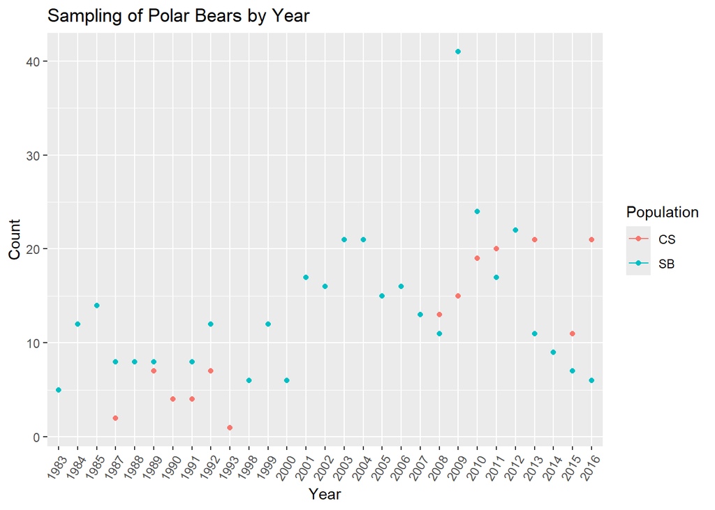

```r
polar_bears <- polar_bears %>%
  mutate(un_creat_ratio = (urea_nitrogen * 0.466) / creatinine)
polar_bears
```

```
## # A tibble: 519 × 12
##    bear_id capture_date popn  sex   age_class mating denning   lat  long
##      <dbl> <date>       <chr> <chr> <chr>     <chr>  <chr>   <dbl> <dbl>
##  1    6398 1985-04-28   SB    F     A         no     yes      70.4 -148.
##  2    6384 1991-04-13   SB    F     A         no     yes      70.0 -150.
##  3    6520 1992-04-18   SB    F     A         no     yes      70.9 -145.
##  4    6559 2000-04-12   SB    F     A         no     yes      70.0 -142.
##  5   20629 2003-04-16   SB    F     A         no     yes      70.5 -145.
##  6   20876 2007-04-01   SB    F     A         no     yes      71.1 -153.
##  7   20354 2009-04-16   SB    F     A         no     yes      70.7 -145.
##  8   21024 2009-04-25   SB    F     A         no     yes      70.5 -147.
##  9   20764 2009-05-01   SB    F     A         no     yes      70.8 -149.
## 10   21045 2009-05-19   SB    F     A         no     yes      70.7 -148.
## # ℹ 509 more rows
## # ℹ 3 more variables: urea_nitrogen <dbl>, creatinine <dbl>,
## #   un_creat_ratio <dbl>
```

```r
polar_bears <- polar_bears %>%
  mutate(fasting=case_when(un_creat_ratio<=10 ~ "fasting",
                           un_creat_ratio> 10 ~ "not_fasting"))
polar_bears
```

```
## # A tibble: 519 × 13
##    bear_id capture_date popn  sex   age_class mating denning   lat  long
##      <dbl> <date>       <chr> <chr> <chr>     <chr>  <chr>   <dbl> <dbl>
##  1    6398 1985-04-28   SB    F     A         no     yes      70.4 -148.
##  2    6384 1991-04-13   SB    F     A         no     yes      70.0 -150.
##  3    6520 1992-04-18   SB    F     A         no     yes      70.9 -145.
##  4    6559 2000-04-12   SB    F     A         no     yes      70.0 -142.
##  5   20629 2003-04-16   SB    F     A         no     yes      70.5 -145.
##  6   20876 2007-04-01   SB    F     A         no     yes      71.1 -153.
##  7   20354 2009-04-16   SB    F     A         no     yes      70.7 -145.
##  8   21024 2009-04-25   SB    F     A         no     yes      70.5 -147.
##  9   20764 2009-05-01   SB    F     A         no     yes      70.8 -149.
## 10   21045 2009-05-19   SB    F     A         no     yes      70.7 -148.
## # ℹ 509 more rows
## # ℹ 4 more variables: urea_nitrogen <dbl>, creatinine <dbl>,
## #   un_creat_ratio <dbl>, fasting <chr>
```

8. (6 points) The authors found that the number of fasting bears increased in the SB population but decreased in the CS population. Make a plot(s) that shows the number of fasting bears by year for both populations to visualize this trend.

[output not shown]

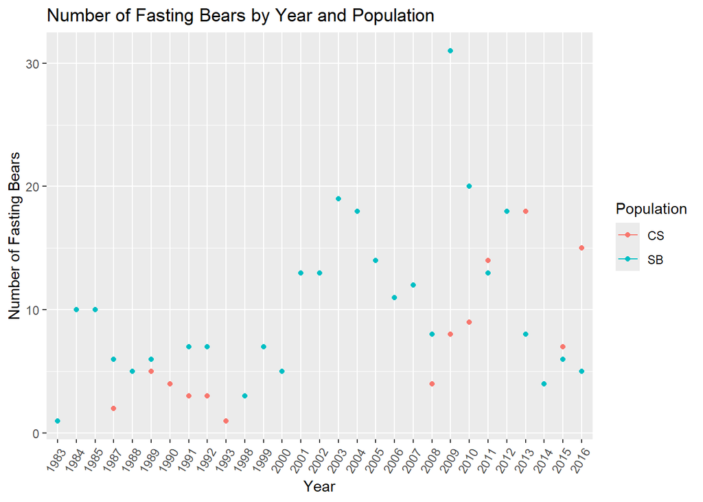

```r
polar_bears %>%
  separate(capture_date, into = c("year", "month", "day"), sep = "-") %>%
  filter(fasting == "fasting") %>%
  group_by(popn, year) %>%
  summarize(count = n()) %>%
  ggplot(aes(x=year, y=count, color=popn))+
  geom_line()+
  geom_point(shape = 16) +
  theme(axis.text.x = element_text(angle = 60, hjust = 1)) +
  labs(title = "Number of Fasting Bears by Year and Population", x="Year", y="Number of Fasting Bears", color = "Population")
```

9. (8 points) Where are the polar bears used in this study located? Make a static (not leaflet) distribution map that shows the locations of bears by population. (hint: use `color=popn` in the `aes()` of `geom_point()`)

```r
polar_bears %>%
  select(lat, long) %>%
  summary()
```

```
##       lat             long
##  Min.   :62.46   Min.   :-172.2
##  1st Qu.:68.11   1st Qu.:-165.2
##  Median :70.53   Median :-150.7
##  Mean   :69.86   Mean   :-153.7
##  3rd Qu.:71.00   3rd Qu.:-146.5
##  Max.   :72.70   Max.   :-134.8
```

```r
lat <- c(62.46, 72.7)
long <- c(-172.2, -134.8)
bbox <- make_bbox(long, lat, f=0.03)
```

```r
map1 <- get_stadiamap(bbox, maptype="stamen_terrain", zoom=6)
```

```
## ℹ © Stadia Maps © Stamen Design © OpenMapTiles © OpenStreetMap contributors.
```

```
## ℹ 48 tiles needed, this may take a while (try a smaller zoom?)
```

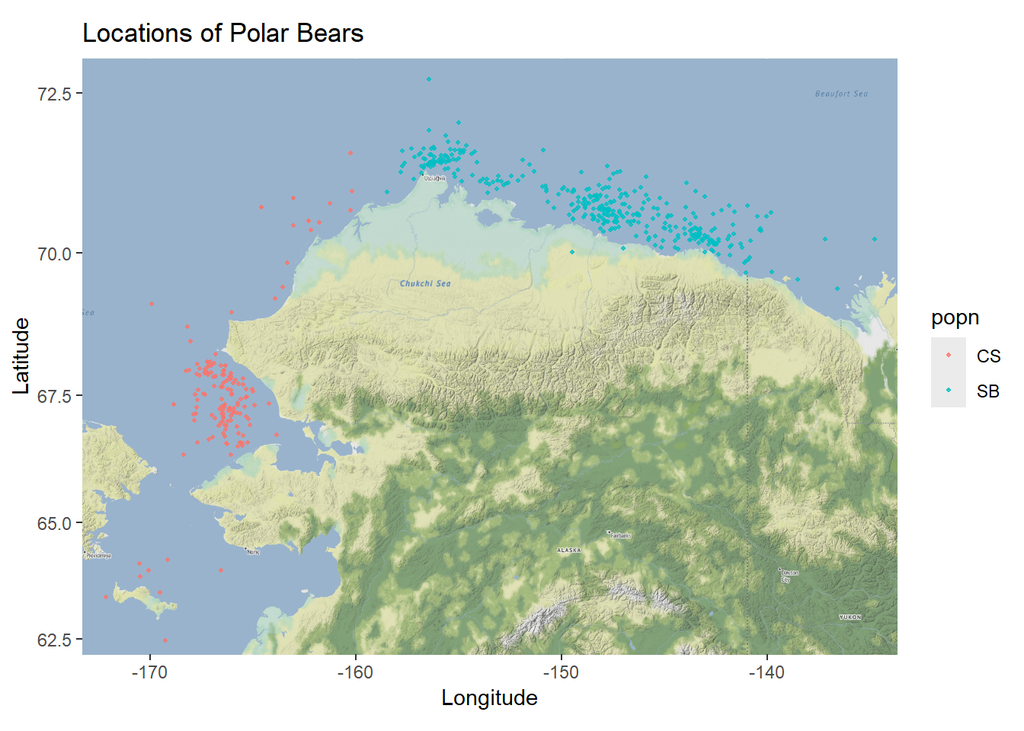

```r
ggmap(map1)+
  geom_point(data=polar_bears, aes(x=long, y=lat, color=popn), size=0.75, alpha=0.8)+
  labs(x="Longitude", y="Latitude", title="Locations of Polar Bears")
```

10. (10 points) Build a simple shiny app that shows the range of `un_creat_ratio` values for both populations. The user should be able to select the fill variable and choose between sex, mating, age_class, denning, and fasting. Please use the code chunk below so that your exam knits.

```r
library(shiny)

ui <- fluidPage(

    selectInput("x",
                "Select Variable",
                choices = c("sex",
                            "mating",
                            "age_class",
                            "denning",
                            "fasting"),
                selected = "sex"),

    plotOutput("plot", width="500px", height="400px")
  )

server <- function(input, output, session) {

output$plot <- renderPlot({

      polar_bears %>%
      ggplot(aes(x = .data[[input$x]],
               y = un_creat_ratio,
               fill = .data[[input$x]])) +
      geom_boxplot(alpha = 0.7) +
      labs(
        title = paste("Range of UN:Creatinine Ratio by", tools::toTitleCase(input$x)),
        x = tools::toTitleCase(input$x),
        y = "UN:Creatinine Ratio",
        fill = tools::toTitleCase(input$x)
      ) +
      theme_minimal(base_size = 14) +
      theme(legend.position = "none")
  })
}

shinyApp(ui, server)
```